# Tooth growth Analysis

Stefaan Delanghe

30 June 2016

Analysis of the ToothGrowth data in the R datasets package.

The response is the length of odontoblasts (teeth) in each of 10 guinea pigs at each of three dose levels of Vitamin C (0.5, 1, and 2 mg) with each of two delivery methods (orange juice or ascorbic acid).

## Load

Loading of the tooth growth dataset

```r
library(datasets)
data(ToothGrowth)
```

## Explore

Exploratory analysis of the tooth growth data set.

```r
str(ToothGrowth)
```

```
## 'data.frame':    60 obs. of  3 variables:
##  $ len : num  4.2 11.5 7.3 5.8 6.4 10 11.2 11.2 5.2 7 ...
##  $ supp: Factor w/ 2 levels "OJ","VC": 2 2 2 2 2 2 2 2 2 2 ...
##  $ dose: num  0.5 0.5 0.5 0.5 0.5 0.5 0.5 0.5 0.5 0.5 ...
```

```r
summary(ToothGrowth)
```

```
##       len        supp         dose
##  Min.   : 4.20   OJ:30   Min.   :0.500
##  1st Qu.:13.07   VC:30   1st Qu.:0.500
##  Median :19.25           Median :1.000
##  Mean   :18.81           Mean   :1.167
##  3rd Qu.:25.27           3rd Qu.:2.000
##  Max.   :33.90           Max.   :2.000
```

```r
colnames(ToothGrowth)
```

```
## [1] "len"  "supp" "dose"
```

```r
head(ToothGrowth)
```

```
##    len supp dose
## 1  4.2   VC  0.5
## 2 11.5   VC  0.5
## 3  7.3   VC  0.5
## 4  5.8   VC  0.5
## 5  6.4   VC  0.5
## 6 10.0   VC  0.5
```

Plot of the tooth growth data set.

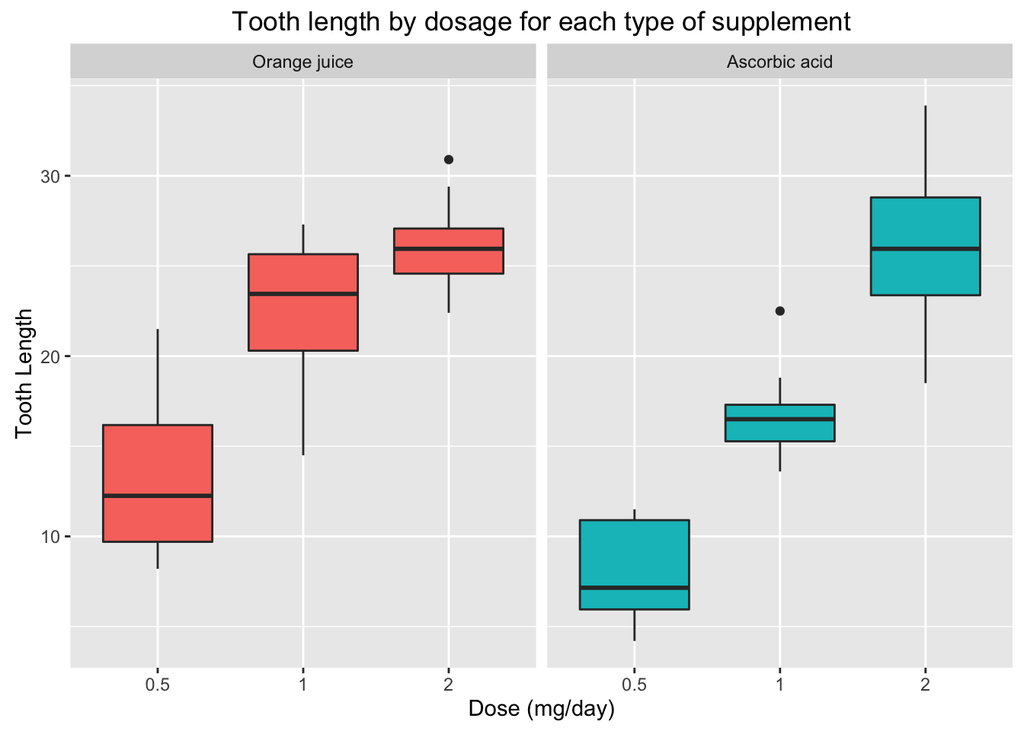

```r
library(ggplot2)
t = ToothGrowth
levels(t$supp) <- c("Orange juice", "Ascorbic acid")
ggplot(t, aes(x=factor(dose), y=len)) +
  facet_grid(.~supp) +
  geom_boxplot(aes(fill = supp), show.legend = FALSE) +
  labs(title="Tooth length by dosage for each type of supplement",
    x="Dose (mg/day)",
    y="Tooth Length")
```

### Exploratory data anlysis

The plot shows that an increase in dose affects to the growth of the tooth for both orange juice and ascorbic acid. We notice that the dose is more effective under that of the Orange juice over that of ascorbic acid for the growth of the tooth. When the dosage gets up 2mg then the effects are the about the same with orange juice and ascorbic acid. When dosage is lower then 2mg the tooth growth is largerly better with orange juice.

## Confidence intervals

### Group differences due to different supplement type

Analyse the group differences related to supplement type.

```r
t.test(len ~ supp, paired = F, var.equal = F, data = ToothGrowth)
```

```
##
##  Welch Two Sample t-test
##
## data:  len by supp
## t = 1.9153, df = 55.309, p-value = 0.06063
## alternative hypothesis: true difference in means is not equal to 0
## 95 percent confidence interval:
##  -0.1710156  7.5710156
## sample estimates:
## mean in group OJ mean in group VC
##         20.66333         16.96333
```

### Dosage factor

Analysis of the data of the correlation between the dose and change of tooth growth.

```r
doseFactLow <- subset(ToothGrowth, dose %in% c(0.5, 1.0))
doseFactMid <- subset(ToothGrowth, dose %in% c(0.5, 2.0))
doseFactHigh <- subset(ToothGrowth, dose %in% c(1.0, 2.0))

t.test(len ~ dose, paired = F, var.equal = F, data = doseFactLow)
```

```
##
##  Welch Two Sample t-test
##
## data:  len by dose
## t = -6.4766, df = 37.986, p-value = 1.268e-07
## alternative hypothesis: true difference in means is not equal to 0
## 95 percent confidence interval:
##  -11.983781  -6.276219
## sample estimates:
## mean in group 0.5   mean in group 1
##            10.605            19.735
```

```r
t.test(len ~ dose, paired = F, var.equal = F, data = doseFactMid)
```

```
##
##  Welch Two Sample t-test
##
## data:  len by dose
## t = -11.799, df = 36.883, p-value = 4.398e-14
## alternative hypothesis: true difference in means is not equal to 0
## 95 percent confidence interval:
##  -18.15617 -12.83383
## sample estimates:
## mean in group 0.5   mean in group 2
##            10.605            26.100
```

```r
t.test(len ~ dose, paired = F, var.equal = F, data = doseFactHigh)
```

```
##
##  Welch Two Sample t-test
##
## data:  len by dose
## t = -4.9005, df = 37.101, p-value = 1.906e-05
## alternative hypothesis: true difference in means is not equal to 0
## 95 percent confidence interval:
##  -8.996481 -3.733519
## sample estimates:
## mean in group 1 mean in group 2
##          19.735          26.100
```

### Supplement factor

Analysis of the correlation between the dose and change tooth growth.

```r
supFactLow <- subset(ToothGrowth, dose == 0.5)
supFactMid <- subset(ToothGrowth, dose == 1.0)
supFactHigh <- subset(ToothGrowth, dose == 2.0)

t.test(len ~ supp, paired = F, var.equal = F, data = supFactLow)
```

```
##
##  Welch Two Sample t-test
##
## data:  len by supp
## t = 3.1697, df = 14.969, p-value = 0.006359
## alternative hypothesis: true difference in means is not equal to 0
## 95 percent confidence interval:
##  1.719057 8.780943
## sample estimates:
## mean in group OJ mean in group VC
##            13.23             7.98
```

```r
t.test(len ~ supp, paired = F, var.equal = F, data = supFactMid)
```

```
##
##  Welch Two Sample t-test
##
## data:  len by supp
## t = 4.0328, df = 15.358, p-value = 0.001038
## alternative hypothesis: true difference in means is not equal to 0
## 95 percent confidence interval:
##  2.802148 9.057852
## sample estimates:
## mean in group OJ mean in group VC
##            22.70            16.77
```

```r
t.test(len ~ supp, paired = F, var.equal = F, data = supFactHigh)
```

```
##
##  Welch Two Sample t-test
##
## data:  len by supp
## t = -0.046136, df = 14.04, p-value = 0.9639
## alternative hypothesis: true difference in means is not equal to 0
## 95 percent confidence interval:
##  -3.79807  3.63807
## sample estimates:
## mean in group OJ mean in group VC
##            26.06            26.14
```

## Conclusion

With the assumptions above we can conclude that a significant difference between the tooth length and the dose between orange juice and ascorbic acid. We have concluded that at 2mg their is not a big difference but for all the other levels (0.5, 1mg) their is a significant difference.

We can say that orange juice is the better dosage delivery but this only up to 2mg. At 2mg their is no difference between the delivery methods.

### Assumptions

Following assumptions have been made

- Population is indepedent.
- Variance between populations are different
- A random population has been used.
- The population was composed of similar guinea pigs.